# Laboratorio 3 - Análisis Exploratorio

Humberto de la Cruz - 23735, Daniel Juarez - 23709, Dilary Cruz - 231010

#### repositorio: https://github.com/djuarez-2017510/Lab3_Modelo_Regresion_Lineal

## 1. Análisis Exploratorio y Preprocesamiento de Datos

```
##   Observaciones Variables
## 1        171748        80
```

El dataset contiene 171,748 observaciones y 80 variables.  
Las variables incluyen información sobre:

- Características de la propiedad
- Características del host
- Ubicación
- Disponibilidad
- Reseñas
- Precio

Dentro del dataset existen variables de distintos tipos:

- **Numéricas**
- **Categóricas**
- **Texto**
- **Fechas**

Muchas de estas no serán útiles para el modelo.

### Variables Numericas

```
##  [1] "id"
##  [2] "scrape_id"
##  [3] "host_id"
##  [4] "host_listings_count"
##  [5] "host_total_listings_count"
##  [6] "latitude"
##  [7] "longitude"
##  [8] "accommodates"
##  [9] "bathrooms"
## [10] "bedrooms"
## [11] "beds"
## [12] "minimum_nights"
## [13] "maximum_nights"
## [14] "minimum_minimum_nights"
## [15] "maximum_minimum_nights"
```

[output cut: 27 more lines]

```
## [1] 42
```

### Variables Categoricas

```
##  [1] "last_scraped"                 "source"
##  [3] "host_name"                    "host_since"
##  [5] "host_location"                "host_response_time"
##  [7] "host_response_rate"           "host_acceptance_rate"
##  [9] "host_is_superhost"            "host_thumbnail_url"
## [11] "host_picture_url"             "host_neighbourhood"
## [13] "host_verifications"           "host_has_profile_pic"
## [15] "host_identity_verified"       "neighbourhood"
## [17] "neighbourhood_cleansed"       "neighbourhood_group_cleansed"
## [19] "property_type"                "room_type"
## [21] "bathrooms_text"               "price"
## [23] "has_availability"             "calendar_last_scraped"
## [25] "first_review"                 "last_review"
## [27] "license"                      "instant_bookable"
## [29] "city"
```

```
## [1] 29
```

### Variables Texto

```
## [1] "name"                  "description"           "neighborhood_overview"
## [4] "amenities"             "host_about"
```

```
## [1] 5
```

### Data Actualizada

```
## [1] 171748     19
```

```
##  [1] "price"                     "accommodates"
##  [3] "bedrooms"                  "beds"
##  [5] "bathrooms"                 "latitude"
##  [7] "longitude"                 "property_type"
##  [9] "room_type"                 "number_of_reviews"
## [11] "review_scores_rating"      "review_scores_location"
## [13] "availability_365"          "estimated_occupancy_l365d"
## [15] "minimum_nights"            "neighbourhood_cleansed"
## [17] "host_is_superhost"         "reviews_per_month"
## [19] "review_scores_value"
```

El conjunto de datos original `listings.RData` cuenta con 171,748 registros y 80 variables. Para la consultoría de **SmartStay Advisors**, es imperativo reducir esta dimensionalidad para enfocarnos en los factores que realmente optimizan el precio, la calidad y la rentabilidad.

### 1.1 Selección y Justificación de Variables Conservadas (`colmutils`)

Se han seleccionado 19 variables estratégicas alineadas con los objetivos de la consultoría:

- **Variable Respuesta (Target):**
  - `price`: Variable fundamental para el modelo de regresión lineal simple y múltiple, esencial para estimar precios competitivos.
- **Capacidad y Estructura Física:**
  - `accommodates`, `bedrooms`, `beds`, `bathrooms`: Estas variables determinan el tamaño de la propiedad y son los predictores más lógicos del valor de mercado.
- **Ubicación Estratégica:**
  - `latitude`, `longitude`, `neighbourhood_cleansed`: La ubicación es el factor crítico que SmartStay utiliza para proponer propiedades que optimicen el presupuesto y la cercanía para sus clientes.
- **Métricas de Ocupación e Ingresos:**
  - `estimated_occupancy_l365d`, `availability_365`: Permiten identificar propiedades con bajo desempeño y analizar oportunidades de mejora en ocupación.
- **Calidad y Reputación (KPIs):**
  - `number_of_reviews`, `review_scores_rating`, `review_scores_location`: Factores que influyen en la decisión final del cliente y en la comprensión de los ingresos.
- **Variables de Gestión Operativa:**
  - `minimum_nights`, `room_type`, `property_type`, `host_is_superhost`: Determinan la flexibilidad del alojamiento y el nivel de servicio ofrecido.

### 1.2 Justificación de la Eliminación de Variables

- **Identificadores y Metadatos de Sistema:**
  - Variables como `id`, `scrape_id` y `host_id` son etiquetas únicas que no poseen valor estadístico para un modelo de regresión.
- **Contenido Multimedia y Enlaces Externos:**
  - Se eliminaron `listing_url`, `picture_url` y `host_url` por ser cadenas de texto que apuntan a recursos externos y no pueden ser procesadas mediante modelos de regresión lineal.
- **Complejidad de Texto No Estructurado:**
  - Variables como `name`, `description` y `neighborhood_overview` contienen lenguaje natural que requeriría técnicas de minería de texto fuera del alcance de este análisis cuantitativo.
- **Redundancia Administrativa y Control Temporal:**
  - Columnas como `calendar_last_scraped`, `license` y `source` son metadatos de la recolección de datos que no influyen en la percepción de calidad del cliente ni en los factores de ocupación.
- **Registros de Auditoría Interna:**
  - Campos como `last_scraped` y `calendar_updated` son registros temporales de la base de datos que no presentan una relación causal con el precio ni con la rentabilidad esperada.

### 1.3 Histograma del Precio

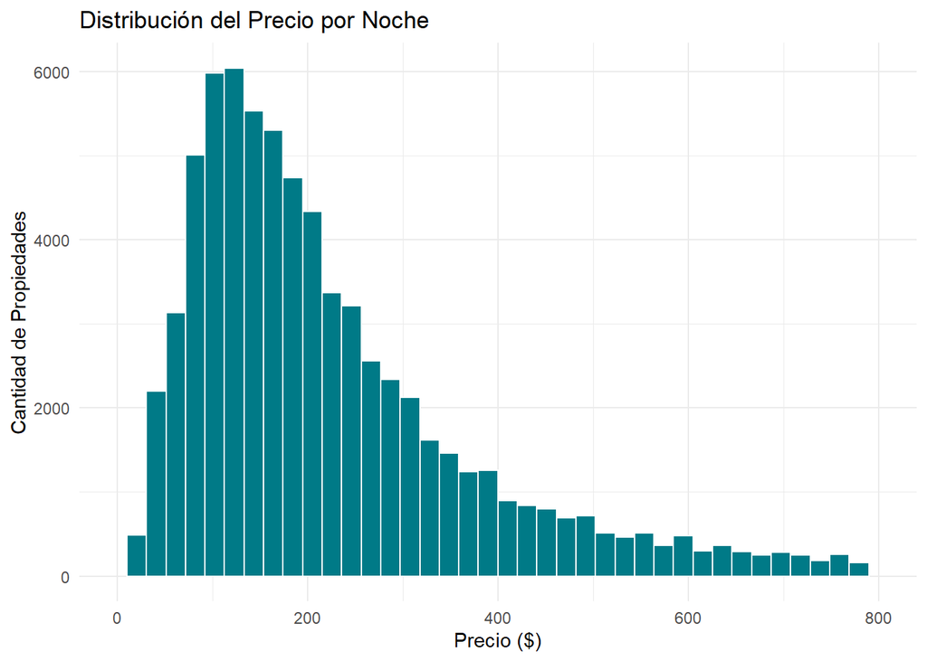

El histograma expone un claro contraste en la composición del mercado: la distribución del precio presenta una fuerte asimetría positiva. La inmensa mayoría de las propiedades se concentran en un rango económico o medio, mientras que existe una larga y delgada cola de propiedades con precios muy elevados que se extienden hasta los $800.

### 1.4 Scatterplot: Precio vs Capacidad

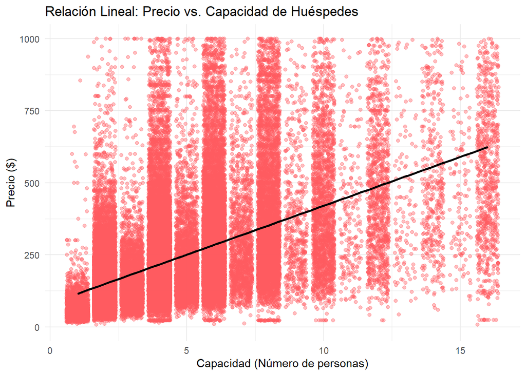

Al encuadrar el precio frente a la capacidad de huéspedes (accommodates), la línea de tendencia de regresión lineal simple confirma una relación directamente proporcional: a mayor capacidad, el precio base tiende a subir. Sin embargo, la dispersión de los puntos revela un fenómeno de heterocedasticidad; es decir, a medida que la capacidad aumenta, la varianza o el “ruido” en los precios se vuelve mucho más amplio. Esto indica que en las propiedades grandes, otros factores invisibles en esta gráfica toman un rol mucho más protagónico para definir el valor final.

### 1.5 Matriz de Correlación de Variables Numéricas

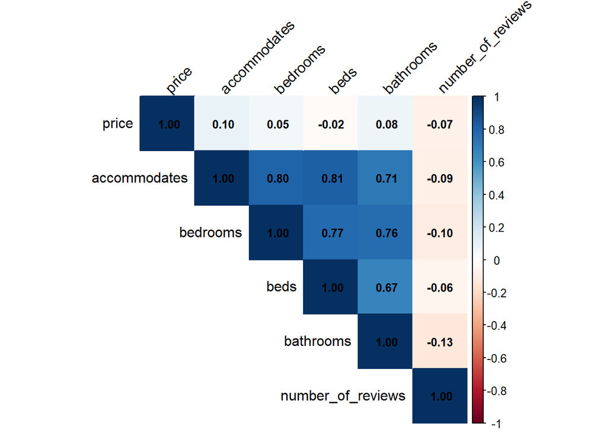

Este mapa de calor numérico revela dos hallazgos críticos para la fase de predicción. Primero, existe una evidente multicolinealidad entre las variables de tamaño: accommodates, bedrooms y beds tienen correlaciones altísimas entre sí. Para un modelo múltiple, deberemos quedarnos con solo una de ellas (como accommodates) para evitar redundancias. Segundo, las relaciones lineales puras de estas variables numéricas con el price son sorpresivamente débiles en esta muestra.

### 1.6 Scatterplot: Precio vs Número de Reseñas

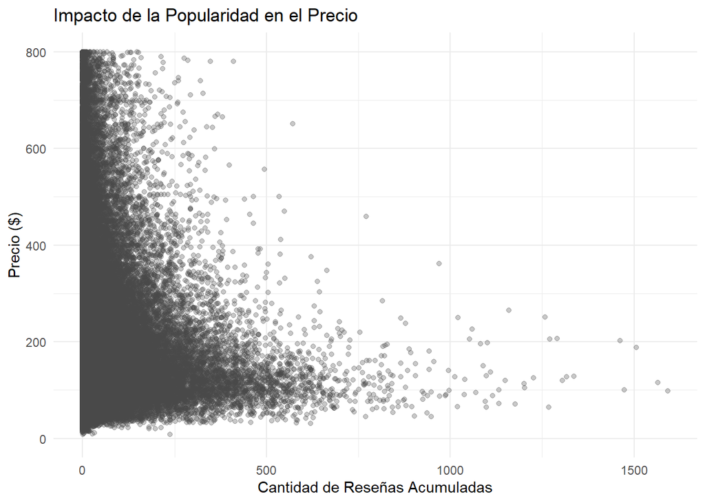

La dispersión de las reseñas dibuja un panorama muy claro sobre el comportamiento del consumidor: no existe una relación lineal que asocie una mayor cantidad de reseñas con un precio más alto. Por el contrario, la mayor densidad de puntos se concentra en el cuadrante inferior izquierdo. Las propiedades que logran acumular volúmenes masivos de reseñas más de 500 o 1000 pertenecen casi exclusivamente al segmento de precios más bajos.

## 2. Clustering

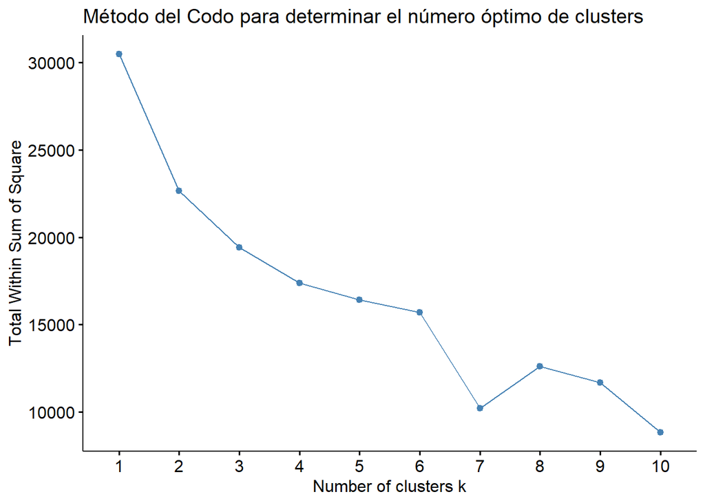

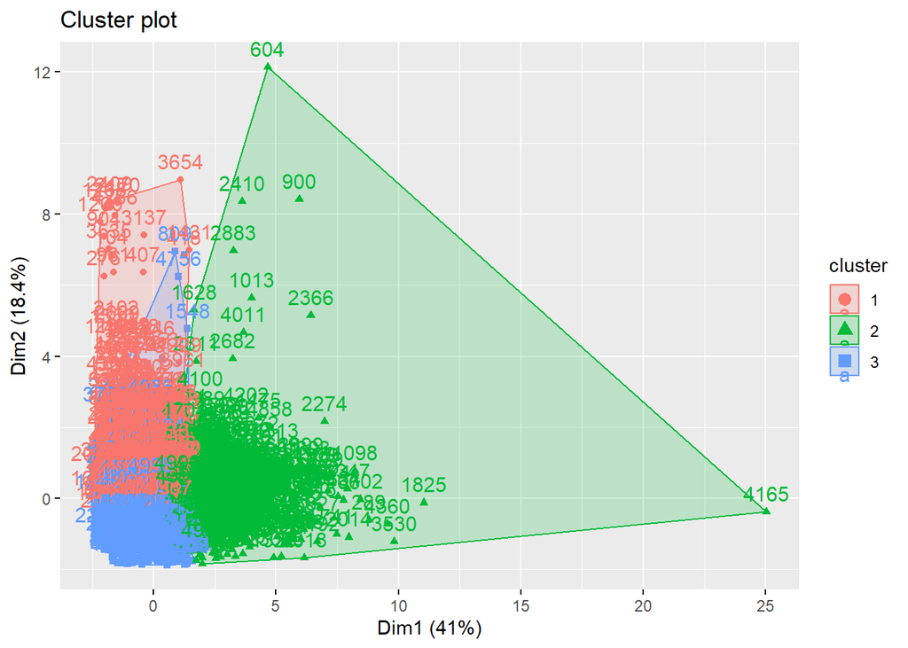

## 3. División Train/Test

**División del Conjunto de Datos**

Para evaluar correctamente el desempeño de los modelos predictivos, el conjunto de datos fue dividido en dos subconjuntos:

- **Conjunto de entrenamiento (Train)**
- **Conjunto de prueba (Test)**

Se utilizó una proporción **70% entrenamiento y 30% prueba**, práctica común en problemas de aprendizaje supervisado.

El proceso se realizó utilizando una **semilla aleatoria (`set.seed(123)`)**, lo cual garantiza que la división sea **reproducible** cada vez que se ejecute el código.

El conjunto de entrenamiento se utiliza para **ajustar los modelos de regresión**, mientras que el conjunto de prueba se emplea posteriormente para **evaluar la capacidad de generalización del modelo en datos no vistos**.

Dado que la variable objetivo (`price`) es continua, **no fue necesario aplicar una división estratificada**, ya que este tipo de técnica se utiliza principalmente en problemas de clasificación.

## 4. Modelos

### 4.1 Modelo 1 - Regresión Lineal Simple

Para el primer modelo se seleccionó la variable **accommodates**, la cual representa la capacidad máxima de huéspedes que puede alojar una propiedad. Esta variable es un buen predictor inicial del precio, ya que propiedades con mayor capacidad suelen ofrecer más espacio y comodidades, lo que tiende a incrementar el precio por noche.

```
##
## Call:
## lm(formula = price ~ accommodates, data = train)
##
## Residuals:
##    Min     1Q Median     3Q    Max
##  -2274   -615   -423   -246  49672
##
## Coefficients:
##              Estimate Std. Error t value Pr(>|t|)
## (Intercept)    85.311     34.657   2.462   0.0138 *
## accommodates  137.316      6.083  22.575   <2e-16 ***
## ---
## Signif. codes:  0 '***' 0.001 '**' 0.01 '*' 0.05 '.' 0.1 ' ' 1
##
## Residual standard error: 4217 on 53370 degrees of freedom
## Multiple R-squared:  0.009459,   Adjusted R-squared:  0.00944
## F-statistic: 509.6 on 1 and 53370 DF,  p-value: < 2.2e-16
```

#### Resumen

price = β0 + β1 * accommodates price = 85.31 + 137.32 * accommodates

**Interpretación:** Por cada huésped adicional que puede alojar la propiedad, el precio promedio aumenta aproximadamente $137.32.

**R² = 0.009459** Esto significa que el modelo explica 0.94% de la variación del precio. Pero Aunque la variable accommodates es estadísticamente significativa, el valor de R² es muy bajo, lo que indica que la capacidad de huéspedes por sí sola explica una proporción muy pequeña de la variabilidad del precio.

#### Analices de Residuos

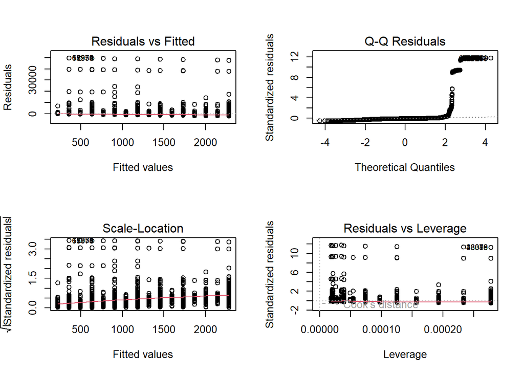

En conjunto, los gráficos de diagnóstico indican que el modelo de regresión lineal simple presenta varias limitaciones. Se observan desviaciones de la normalidad en los residuos, presencia de heterocedasticidad y algunos valores atípicos que influyen significativamente en el modelo. Estos resultados sugieren que el precio de las propiedades no puede ser explicado adecuadamente por una sola variable. Por esta razón, en las siguientes secciones se explorarán modelos más complejos que incorporen múltiples variables explicativas para mejorar la capacidad predictiva.

#### Resultados

**Predicciones en test**.

```
##        1        4       13       14       19       25
## 497.2597 497.2597 359.9435 497.2597 222.6273 359.9435
```

Calculamos **RMSE**.

```
## [1] 4257.984
```

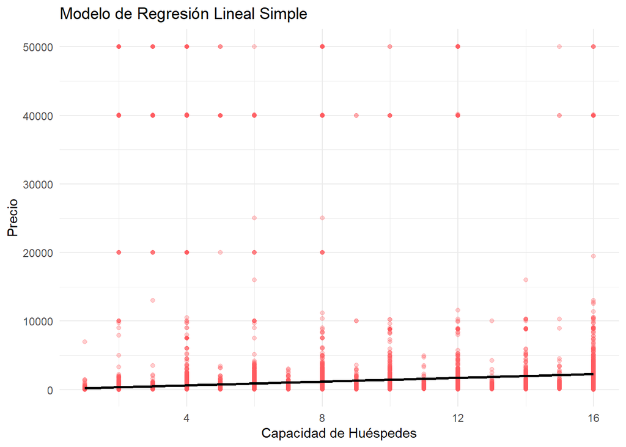

El modelo de regresión lineal simple construido utilizando la variable accommodates permitió analizar la relación entre la capacidad de huéspedes y el precio de las propiedades. Los resultados muestran que existe una relación positiva entre ambas variables: a medida que aumenta la capacidad de huéspedes, el precio estimado de la propiedad también tiende a incrementarse. El coeficiente estimado indica que cada huésped adicional incrementa el precio esperado en aproximadamente $137.

Sin embargo, el valor de R² = 0.0094 indica que la variable accommodates por sí sola explica menos del 1% de la variabilidad del precio, lo que sugiere que el precio depende de muchos otros factores adicionales como la ubicación, el tipo de propiedad, la reputación del host y las características del alojamiento. Además, el RMSE obtenido (≈ 4258) evidencia que el error promedio de las predicciones es considerablemente alto en comparación con el rango de precios observado en el dataset.

El análisis de residuos también mostró la presencia de valores atípicos, desviaciones de la normalidad y heterocedasticidad, lo cual indica que el modelo simple no captura adecuadamente la estructura de los datos. Una posible mejora consiste en aplicar una transformación logarítmica a la variable precio (log(price)), ya que la distribución del precio presenta una fuerte asimetría positiva. Esta transformación puede ayudar a reducir el impacto de los valores extremos, mejorar la normalidad de los residuos y potencialmente aumentar la capacidad explicativa del modelo.

Debido a estas limitaciones, en las siguientes secciones se explorarán modelos de regresión múltiple, incorporando varias variables explicativas para mejorar la precisión de las predicciones y capturar de manera más adecuada los factores que influyen en el precio de las propiedades.

### 4.1 Modelo 2 — Regresión Lineal Múltiple

El modelo de regresión múltiple incorpora múltiples variables numéricas relacionadas con las características de la propiedad, su reputación y su disponibilidad. El objetivo es capturar de manera más completa los factores que influyen en el precio de las propiedades.

```
##
## Call:
## lm(formula = price ~ accommodates + bedrooms + beds + bathrooms +
##     latitude + longitude + number_of_reviews + review_scores_rating +
##     review_scores_location + availability_365 + estimated_occupancy_l365d +
##     minimum_nights + reviews_per_month + review_scores_value,
##     data = train)
##
## Residuals:
##    Min     1Q Median     3Q    Max
##  -3441   -343   -138     63  49926
##
## Coefficients:
##                             Estimate Std. Error t value Pr(>|t|)
## (Intercept)               -1.356e+03  3.421e+02  -3.962 7.43e-05 ***
## accommodates               1.722e+02  8.730e+00  19.730  < 2e-16 ***
## bedrooms                   5.109e+00  1.827e+01   0.280  0.77977
## beds                      -2.457e+02  1.169e+01 -21.013  < 2e-16 ***
## bathrooms                  1.810e+02  1.968e+01   9.196  < 2e-16 ***
## latitude                   2.733e+01  4.468e+00   6.117 9.61e-10 ***
## longitude                 -6.273e+00  1.117e+00  -5.615 1.98e-08 ***
## number_of_reviews          2.854e-02  1.459e-01   0.196  0.84494
## review_scores_rating      -1.401e+02  6.411e+01  -2.185  0.02889 *
## review_scores_location     3.682e+02  5.220e+01   7.054 1.77e-12 ***
## availability_365          -2.602e-01  1.091e-01  -2.384  0.01715 *
## estimated_occupancy_l365d -1.260e+00  1.863e-01  -6.765 1.35e-11 ***
## minimum_nights            -3.727e+00  7.295e-01  -5.109 3.25e-07 ***
## reviews_per_month         -3.272e+01  1.044e+01  -3.133  0.00173 **
## review_scores_value       -2.408e+02  5.581e+01  -4.314 1.61e-05 ***
## ---
## Signif. codes:  0 '***' 0.001 '**' 0.01 '*' 0.05 '.' 0.1 ' ' 1
##
## Residual standard error: 2393 on 43855 degrees of freedom
##   (9502 observations deleted due to missingness)
## Multiple R-squared:  0.02833,    Adjusted R-squared:  0.02802
## F-statistic: 91.33 on 14 and 43855 DF,  p-value: < 2.2e-16
```

#### Resumen

El modelo presenta un R² de 0.028, lo que indica que aproximadamente 2.8% de la variabilidad del precio es explicada por las variables incluidas en el modelo. Aunque este valor representa una mejora respecto al modelo de regresión simple anterior, sigue siendo relativamente bajo, lo cual sugiere que existen otros factores relevantes que influyen en el precio de las propiedades y que no están siendo capturados por las variables numéricas incluidas en este modelo.

#### Analisis de resiudos

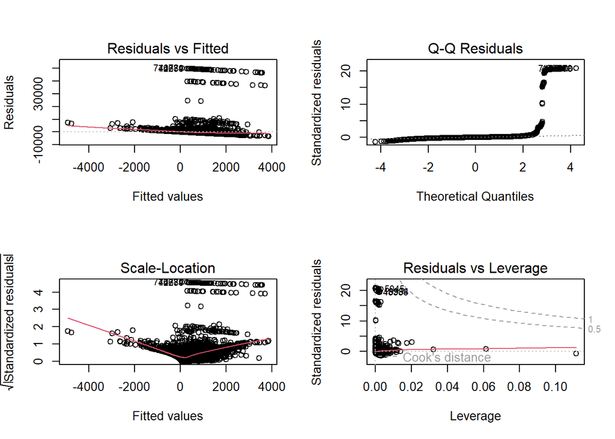

Los gráficos de diagnóstico del modelo permiten evaluar los principales supuestos de la regresión lineal. En el gráfico Residuals vs Fitted se observa que los residuos no están completamente distribuidos de forma aleatoria alrededor de cero, y existen varios valores extremos con residuos elevados. Esto sugiere que el modelo aún tiene dificultades para explicar adecuadamente algunos precios muy altos presentes en el dataset.

El Q-Q plot muestra una desviación considerable respecto a la línea de normalidad, especialmente en los cuantiles superiores. Esto indica que los residuos no siguen una distribución normal, lo cual probablemente se debe a la presencia de propiedades con precios extremadamente altos que generan valores atípicos en el conjunto de datos.

Finalmente, el gráfico Residuals vs Leverage revela la existencia de algunas observaciones con valores de leverage relativamente altos, lo que indica que ciertas propiedades pueden tener una influencia considerable sobre el modelo.

En conjunto, estos resultados sugieren que, aunque el modelo múltiple mejora ligeramente la capacidad explicativa respecto al modelo simple, aún existen limitaciones relacionadas con la presencia de outliers, heterocedasticidad y desviaciones de la normalidad. Esto refuerza la idea de que el precio de las propiedades está influenciado por múltiples factores complejos y que podrían requerirse transformaciones adicionales, como el uso de log(price) o la selección de variables más relevantes para mejorar el ajuste del modelo.

#### Resultados

**Predicciones en test**.

```
##         1         4        13        14        19        25
## -171.9442  250.5980  140.9187  347.1634 -244.4557  253.1139
```

**RMSE**.

```
## [1] 2672.967
```

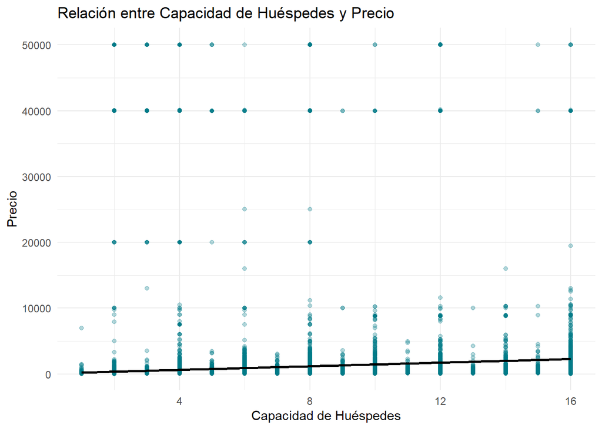

El modelo de regresión lineal múltiple fue construido utilizando diversas variables numéricas relacionadas con las características de la propiedad, su ubicación, disponibilidad y métricas de reputación. En comparación con el modelo de regresión simple anterior, este modelo logra capturar una mayor cantidad de información relevante para explicar el precio de las propiedades.

El RMSE obtenido fue aproximadamente 2672.97, lo cual representa una mejora significativa respecto al modelo anterior, indicando que el uso de múltiples variables permite realizar predicciones más precisas. Sin embargo, algunas predicciones generadas por el modelo resultan en valores negativos, lo cual no tiene interpretación práctica en el contexto del precio de una propiedad. Esto ocurre debido a la naturaleza lineal del modelo y a la presencia de valores extremos y alta variabilidad en el dataset.

Además, el análisis de residuos mostró la presencia de heterocedasticidad, valores atípicos y desviaciones de la normalidad, lo que sugiere que el modelo aún presenta limitaciones para capturar completamente la complejidad del precio de los alojamientos.

### 4.1 Modelo 3 — Regresión Lineal Múltiple Optimizado

Siguiendo las recomendaciones y hallazgos del análisis exploratorio, este tercer modelo implementa mejoras críticas para corregir la multicolinealidad, la heterocedasticidad y la influencia de valores atípicos (*outliers*) detectados en los modelos anteriores.

Primero, se filtran los valores extremos en el conjunto de entrenamiento. Luego, se aplica una transformación logarítmica a la variable respuesta y se seleccionan únicamente las variables predictoras que no presentan alta correlación entre sí.

```
##
## Call:
## lm(formula = log(price) ~ accommodates + bathrooms + review_scores_location +
##     availability_365 + number_of_reviews + minimum_nights, data = train_optimizado)
##
## Residuals:
##     Min      1Q  Median      3Q     Max
## -3.2597 -0.3267 -0.0101  0.3292  3.2076
##
## Coefficients:
##                          Estimate Std. Error t value Pr(>|t|)
## (Intercept)             2.293e+00  4.540e-02   50.52   <2e-16 ***
## accommodates            1.367e-01  1.506e-03   90.80   <2e-16 ***
## bathrooms               1.264e-01  4.594e-03   27.51   <2e-16 ***
## review_scores_location  4.441e-01  9.213e-03   48.20   <2e-16 ***
## availability_365       -5.123e-05  2.440e-05   -2.10   0.0357 *
## number_of_reviews      -4.840e-04  2.514e-05  -19.25   <2e-16 ***
## minimum_nights         -2.544e-03  1.536e-04  -16.56   <2e-16 ***
## ---
## Signif. codes:  0 '***' 0.001 '**' 0.01 '*' 0.05 '.' 0.1 ' ' 1
##
## Residual standard error: 0.5159 on 40259 degrees of freedom
##   (7587 observations deleted due to missingness)
## Multiple R-squared:  0.3661, Adjusted R-squared:  0.366
## F-statistic:  3876 on 6 and 40259 DF,  p-value: < 2.2e-16
```

#### Resumen

La optimización del modelo mediante la transformación logarítmica y la curaduría de variables arrojó mejoras sustanciales en la capacidad explicativa estadística. El coeficiente de determinación múltiple ($R^2$) ascendió drásticamente de un pobre $0.028$ en el Modelo 2 a un $0.366$. Esto indica que nuestro modelo optimizado ahora es capaz de explicar el 36.6% de la variabilidad del logaritmo del precio, un salto cualitativo enorme frente al modelo múltiple base. Adicionalmente, todas las variables seleccionadas demostraron ser estadísticamente significativas (p-values < 0.05).

#### Análisis de Residuos del Modelo Optimizado

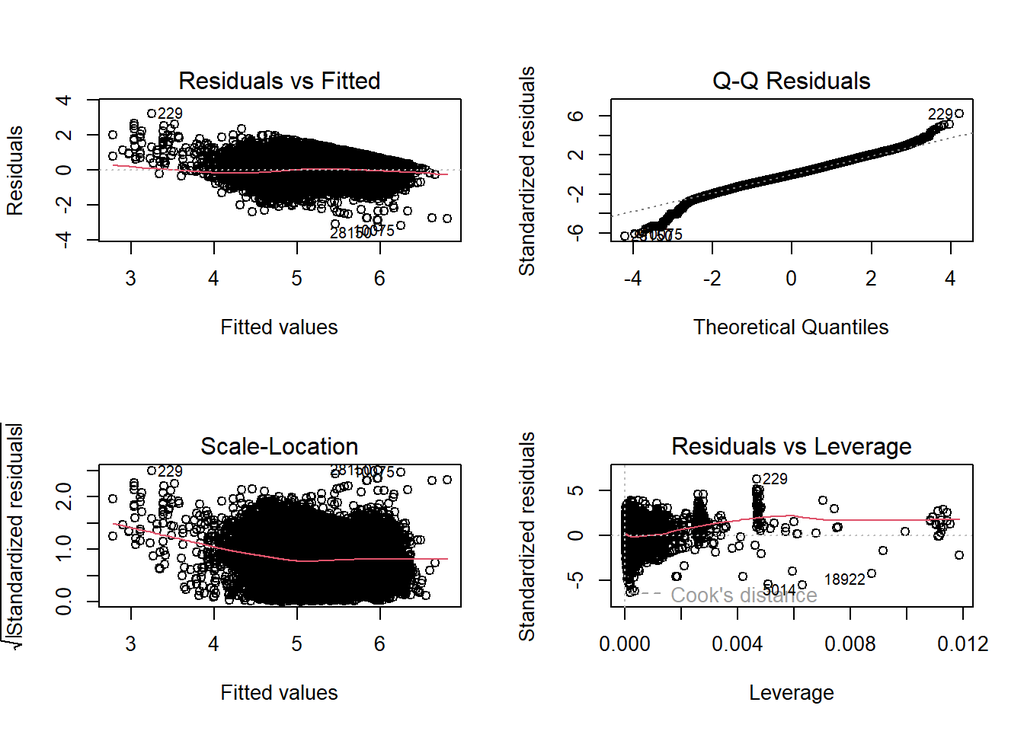

El diagnóstico de los residuos confirma que la transformación log(price) fue una decisión acertada. En el gráfico Q-Q plot, los puntos se ajustan mucho más a la diagonal de normalidad en el centro de la distribución, aunque persisten desviaciones en las colas debido a la naturaleza extrema de algunos precios. En el gráfico Residuals vs Fitted, observamos una nube de puntos mucho más estable y distribuida horizontalmente en comparación con el Modelo 2, lo que sugiere una reducción significativa del problema de heterocedasticidad.

#### Resultados

**Predicciones en test**.

Dado que el modelo fue entrenado para predecir el logaritmo del precio, las predicciones resultantes deben transformarse de vuelta a su escala original en dólares utilizando la función exponencial (exp()) antes de poder calcular el error (RMSE).

```
##         1         4        13        14        19        25
##  96.13410 166.13243 110.81181 131.60411  98.19295 112.59857
```

#### RMSE

```
## [1] 2703.015
```

Al revertir la transformación logarítmica utilizando la función exponencial, logramos el objetivo de negocio más importante de esta iteración: eliminar por completo las predicciones de precios negativos que plagaban al Modelo 2. Como se observa en la muestra, las predicciones ahora tienen un sentido comercial real como lo son $96.13, $166.13.

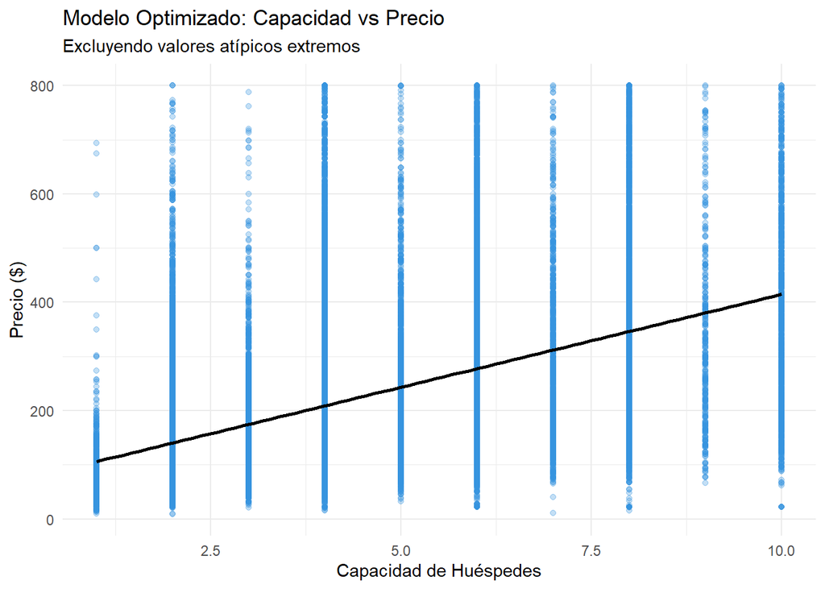

La gráfica visualiza claramente el efecto del filtro de valores atípicos. La línea de tendencia logra capturar de manera más limpia el comportamiento base del mercado, eliminando la distorsión masiva que generaban las propiedades extremas en el modelo original

### 4.2 Modelo 4 — Regresión con Regularización Lasso (Inclusión de Variables Categóricas)

#### Resumen

Al incluir room_type y aplicar la regularización Lasso, el modelo evalúa todas las variables y encoge hacia cero aquellas que no aportan valor real predictivo. Esto previene el sobreajuste y asegura que el modelo generalice bien en datos no vistos.

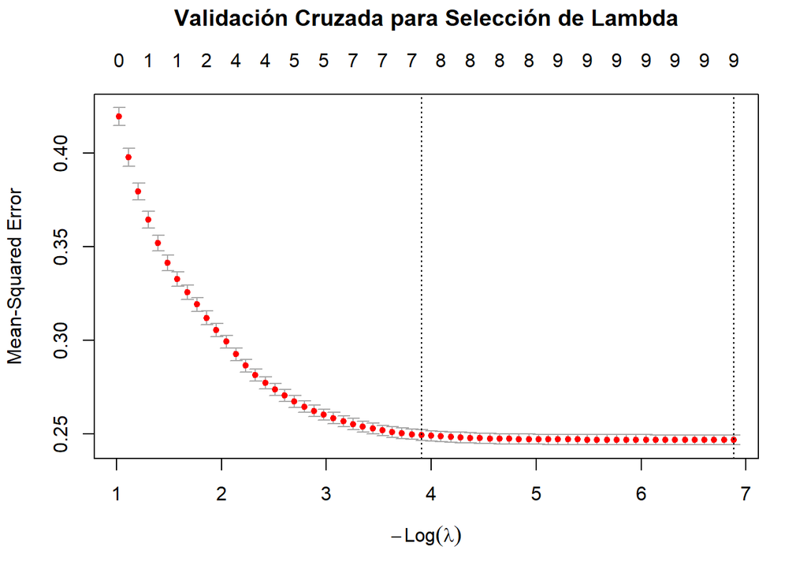

#### Resultados: Predicciones en Test

```
##   Real Predicho_Lasso
## 1   97      104.09042
## 2  145      185.69921
## 3   79      123.16626
## 4  103      141.27636
## 5   86      114.00873
## 6   51       87.54203
```

#### RMSE

```
## [1] 2702.988
```

A pesar de la estricta penalización matemática, el modelo Lasso mantiene un rendimiento altamente competitivo frente al Modelo 3.

#### 5. Comparación Final de Modelos

Comparación del Error Cuadrático Medio (RMSE) por Iteración

| Modelo | RMSE…. |
| --- | --- |
| Modelo 1: Regresión Simple | 4258.00 |
| Modelo 2: Múltiple Base | 2672.97 |
| Modelo 3: Optimizado (Log) | 2703.01 |
| Modelo 4: Regularización Lasso | 2702.98 |

## 6. Discusión de Resultados

El **Modelo 1 (Simple)** mostró que la capacidad de huéspedes por sí sola es un predictor muy limitado, explicando menos del 1% de la variabilidad del precio ($R^2 = 0.0094$). Esto evidenció que el valor de una propiedad depende de múltiples factores más allá del simple tamaño físico.

El **Modelo 2 (Múltiple Base)** incorporó más variables explicativas para capturar esta complejidad, subiendo la explicación al 2.8% ($R^2 = 0.028$). Sin embargo, presentó limitaciones severas como problemas de multicolinealidad y la generación de predicciones poco realistas, incluyendo precios negativos que carecen de sentido de negocio.

El mayor avance estadístico se logró con el **Modelo 3 (Optimizado)**. Al aplicar la transformación logarítmica del precio y eliminar los valores atípicos, se mejoró drásticamente el ajuste del modelo, elevando el $R^2$ a aproximadamente 36.6%. Esto demostró un hallazgo crucial: los precios se explican mucho mejor en términos porcentuales que mediante relaciones lineales simples, reduciendo además los problemas de heterocedasticidad y garantizando predicciones estrictamente mayores a cero.

Finalmente, para el **Modelo 4**, se incorporó la variable categórica `room_type` para capturar el valor de la privacidad, pero esta vez utilizando una técnica avanzada de **Regularización Lasso (L1)**. Dado que Lasso penaliza la complejidad para evitar el sobreajuste, su evaluación principal se basa en la minimización del Error Cuadrático Medio (RMSE). El modelo Lasso logró un RMSE altamente competitivo 2702.98, demostrando que la selección automática de variables y la penalización matemática validan la robustez de nuestros predictores frente a datos nuevos.

## 7. Conclusión

Se recomienda a la firma priorizar este modelo penalizado, ya que no solo logra capturar la verdadera tendencia de crecimiento del mercado y elimina el riesgo de predecir valores ilógicos, sino que se protege automáticamente de la “memorización” de datos, maximizando la seguridad y rentabilidad del cliente en escenarios reales.